# Progetto Metodi finanziari

GRUPPO

2 maggio 2018

# File con i passaggi per analisi su start up

Apro librerie necessarie

```r
library(tidyverse)
library(readxl)
```

Importo dati da excel

```r
DS <- read_excel("C:/Users/SuperOrso1/Desktop/Metodi finanziari/Progetto/dataset_fb03.xlsx")
```

Elimino le non start up

```r
DS_1 <- DS %>%
        filter (Startup_dummy=="si")
```

Elimino chi non ha almeno un si nei requisiti

```r
DS_1 <- DS_1 %>%
        filter (req_1=="SI"|req_2=="SI"|req_3=="SI")
```

Seleziono le variabili di mio interesse

```r
DS_2 <- DS_1 %>%
        select (Nome,Data_bilancio, ROA,EBITDAmarg,RotazCapInv,IndiIndipFin,IndCorr,Sede_Longitudine,Sede_Latitudine,Website,ATECO_codice,Dipendenti,Data_creazione,PrevFemm_red,PrevGiov_red,Sede_regione)
```

Voglio solo chi ha nel bilancio 2016 Quindi prima scompongo data poi tengo solo i 2016

```r
DS_3 <- DS_2 %>%
        separate("Data_bilancio", c("Anno", "Mese", "Giorno"), sep = "-")
DS_3 <- DS_3 %>%
        filter(Anno=="2016")
```

Scompongo data di creazione

```r
DS_3 <- DS_3 %>%
        separate("Data_creazione", c("Anno", "Mese", "Giorno"), sep = "-")
```

guardo settore informatico ateco 62:

prendo solo primi 2 numeri codice ateco

```r
DS_4$Ateco_2 <- substr(DS_4$ATECO_codice, start = 1, stop = 2)
```

ora creo dummy

```r
DS_4$informatica <- as.numeric(DS_4$Ateco_2 == 62)
```

guardo quanti sono

```r
DS_4$informatica <- as.factor(DS_4$informatica)
DS_4 %>%
    count(informatica)
```

```
## # A tibble: 2 x 2
##   informatica     n
##   <fct>       <int>
## 1 0            1394
## 2 1             642
```

Seleziono solo aziende informatiche

```r
DS_4<-    DS_4 %>%
          filter(informatica==1)
```

## faccio pulizia degli outlier:

inizio con roa

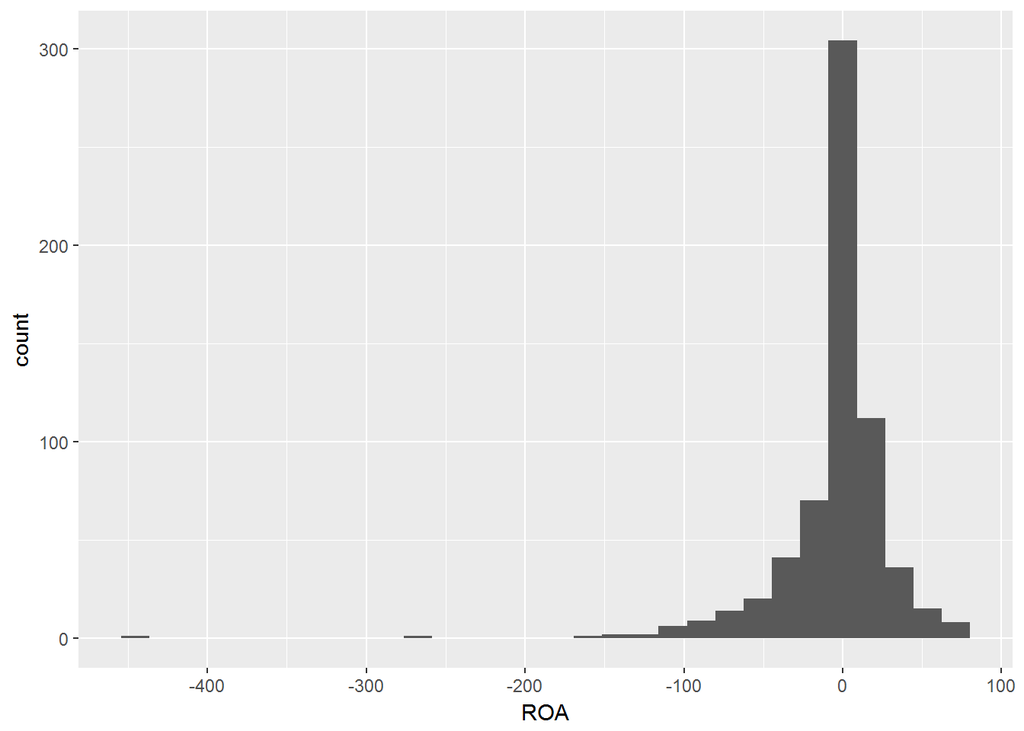

```r
ggplot(data=DS_4,
       mapping=aes(x=ROA))+
geom_histogram()
```

```r
summary(DS_4$ROA)
```

```
##     Min.  1st Qu.   Median     Mean  3rd Qu.     Max.
## -438.120   -9.945    2.235   -3.897   10.040   78.740
```

```r
quantile(DS_4$ROA,0.01)
```

```
##        1%
## -115.0211
```

guardo rotazione capitale investito

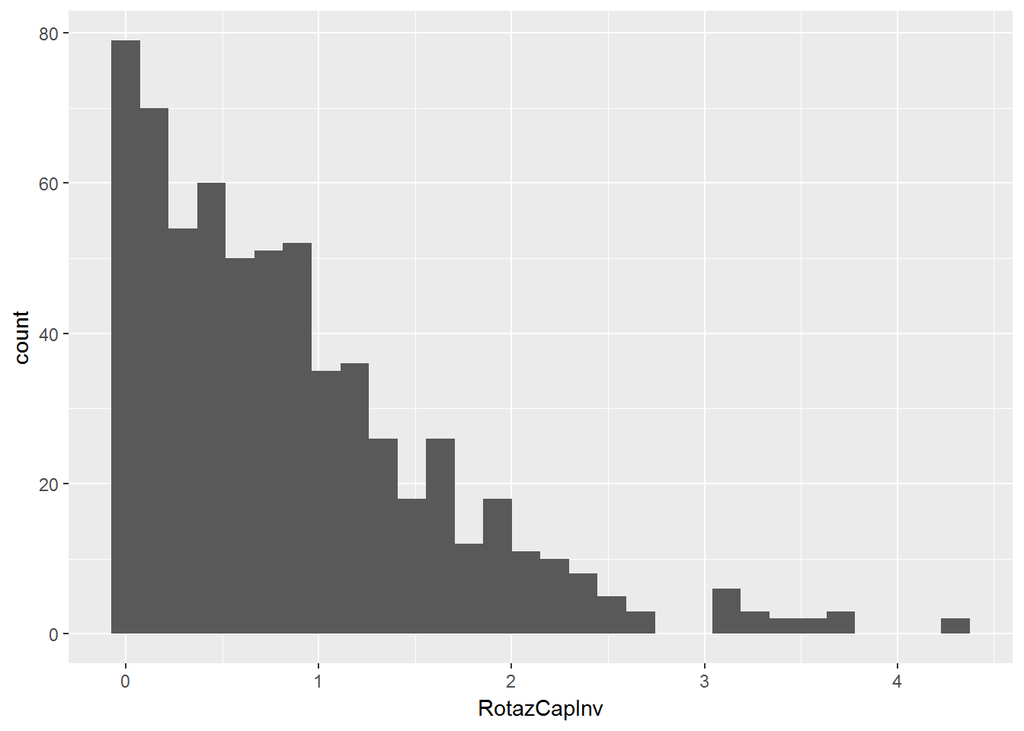

```r
ggplot(data=DS_4,
       mapping=aes(x=RotazCapInv))+
geom_histogram()
```

```r
summary(DS_4$RotazCapInv)
```

```
##    Min. 1st Qu.  Median    Mean 3rd Qu.    Max.
##  0.0000  0.2600  0.6850  0.8602  1.2375  4.3000
```

guardo ebitda margin

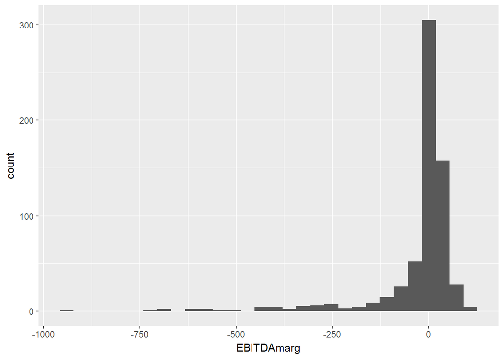

```r
ggplot(data=DS_4,
       mapping=aes(x=EBITDAmarg))+
geom_histogram()
```

```r
summary(DS_4$EBITDAmarg)
```

```
##     Min.  1st Qu.   Median     Mean  3rd Qu.     Max.
## -949.170   -8.015    7.285  -22.759   21.755   99.850
```

```r
quantile(DS_4$EBITDAmarg,0.01)
```

```
##       1%
## -588.247
```

taglio - 500 e vedo come viene

```r
DS_5 <- DS_4 %>%
       filter(EBITDAmarg>-500)
```

guardo indice indipendenza finanziaria

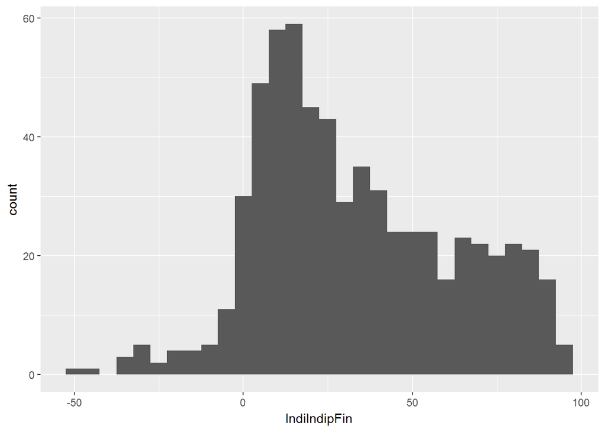

```r
ggplot(data=DS_5,
       mapping=aes(x=IndiIndipFin))+
geom_histogram()
```

```r
summary(DS_4$IndiIndipFin)
```

```
##    Min. 1st Qu.  Median    Mean 3rd Qu.    Max.
##  -48.40   11.23   27.03   33.23   55.02   96.59
```

guardo corrente

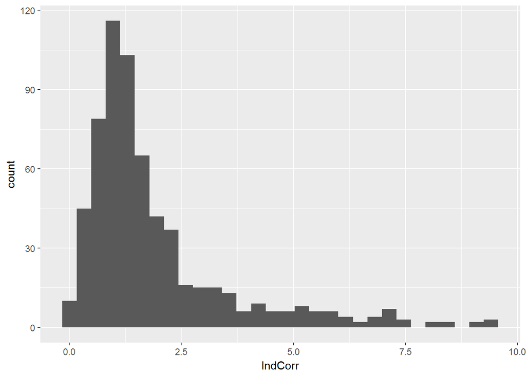

```r
ggplot(data=DS_5,
       mapping=aes(x=IndCorr))+
geom_histogram()
```

```r
summary(DS_4$IndCorr)
```

```
##    Min. 1st Qu.  Median    Mean 3rd Qu.    Max.
##   0.030   0.910   1.305   1.930   2.230   9.440
```

## mappare sull’italia

mappa regioni per start-up

```r
library(devtools)
install_github("nicolasturaro/mapIT")
```

apro library

```r
library(mapIT)
```

creo data frame per regioni

```r
DS_regio <-DS_5 %>%
          select(Nome,Dipendenti,Sede_regione)
DS_regio <- na.omit(DS_regio)
DS_regio_1<- DS_regio %>%
             count(Sede_regione)

DS_regio_1$Sede_regione[DS_regio_1$Sede_regione == "Valle d'Aosta/Vallée d'Aoste"] <- "Valle d'Aosta"
DS_regio_1 <- as.data.frame(DS_regio_1)
```

creo mappa start up per regioni

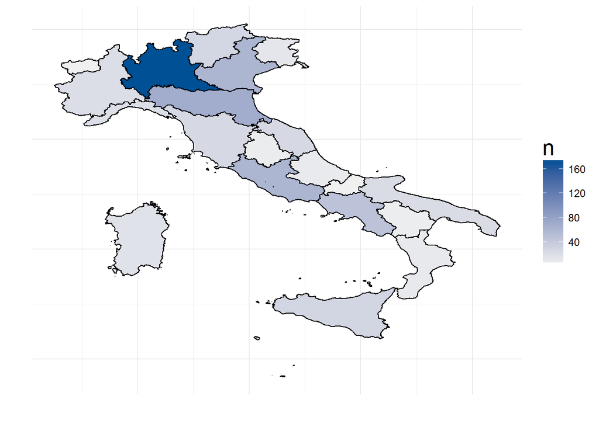

```r
mapIT(n, Sede_regione, data=DS_regio_1)
```

## Inizio analisi componenti principali dopo pulizia

library componenti principali

```r
dati<-as.data.frame(DS_5)
```

```r
library(Rcmdr)
library(psych)
```

```r
library(FactoMineR)
```

PCA su factoMineR

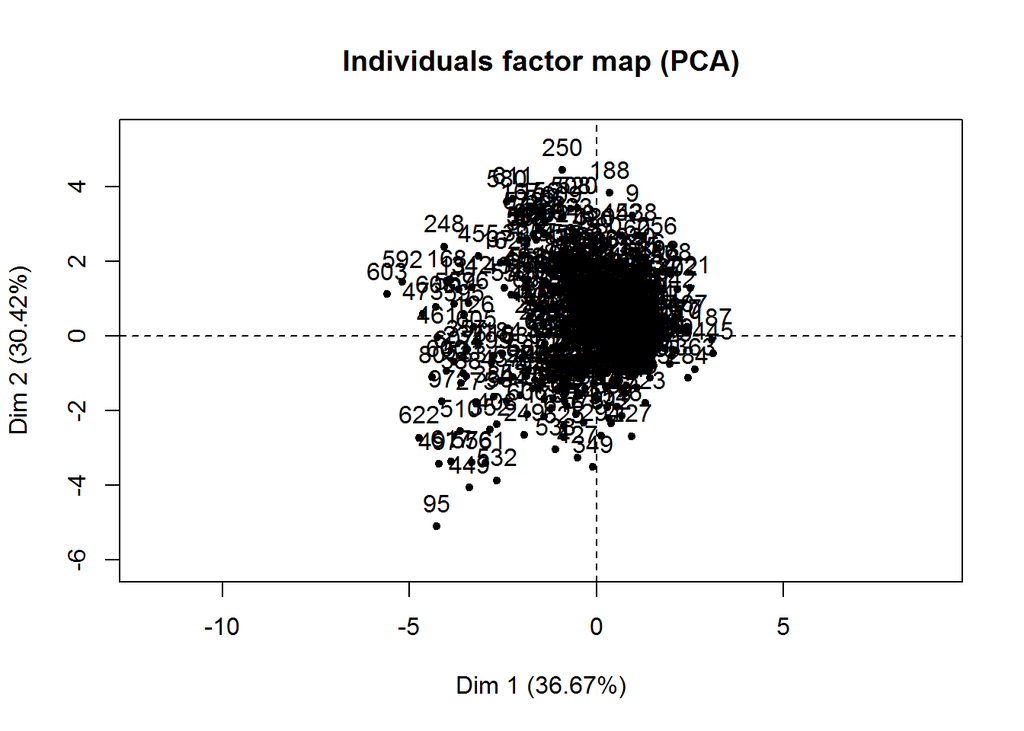

```r
dati.PCA<-dati[, c("ROA", "EBITDAmarg", "RotazCapInv", "IndiIndipFin",
  "IndCorr")]
res<-PCA(dati.PCA , scale.unit=TRUE, ncp=5, graph = FALSE)
plot.PCA(res, axes=c(1, 2), choix="ind", habillage="none", col.ind="black",
  col.ind.sup="blue", col.quali="magenta", label=c("ind", "ind.sup", "quali"),
  new.plot=TRUE)
```

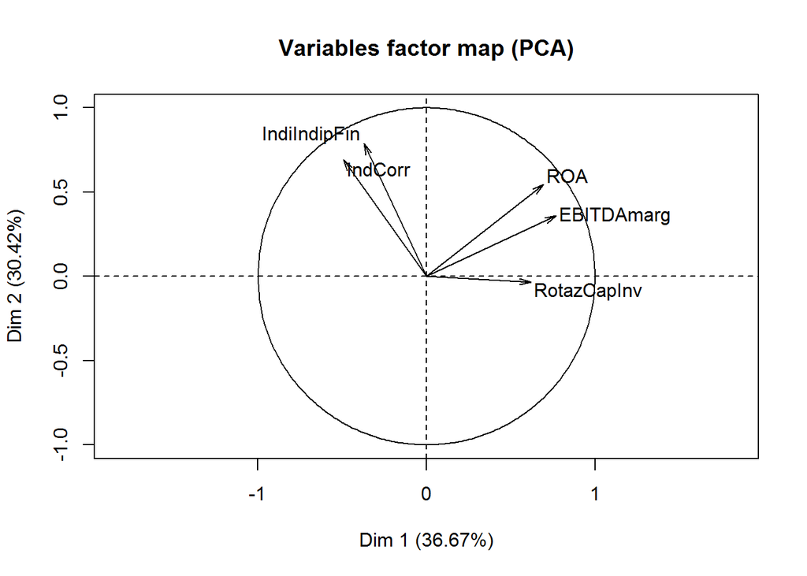

```r
plot.PCA(res, axes=c(1, 2), choix="var", new.plot=TRUE, col.var="black",
  col.quanti.sup="blue", label=c("var", "quanti.sup"), lim.cos2.var=0)
```

```r
summary(res, nb.dec = 3, nbelements=10, nbind = 10, ncp = 3, file="")
```

```
##
## Call:
## PCA(X = dati.PCA, scale.unit = TRUE, ncp = 5, graph = FALSE)
##
##
## Eigenvalues
##                        Dim.1   Dim.2   Dim.3   Dim.4   Dim.5
## Variance               1.833   1.521   0.783   0.493   0.370
## % of var.             36.666  30.424  15.653   9.857   7.401
## Cumulative % of var.  36.666  67.089  82.742  92.599 100.000
##
## Individuals (the 10 first)
##                  Dist    Dim.1    ctr   cos2    Dim.2    ctr   cos2
## 1            |  0.971 |  0.891  0.069  0.843 | -0.238  0.006  0.060 |
## 2            |  0.801 |  0.547  0.026  0.466 | -0.145  0.002  0.033 |
## 3            |  2.109 | -1.122  0.109  0.283 |  1.243  0.161  0.347 |
## 4            |  1.153 |  0.785  0.053  0.464 | -0.787  0.064  0.466 |
## 5            |  1.889 |  1.064  0.098  0.317 |  0.416  0.018  0.049 |
## 6            |  3.525 | -2.043  0.360  0.336 |  2.578  0.691  0.535 |
## 7            |  0.858 |  0.300  0.008  0.122 | -0.672  0.047  0.614 |
## 8            |  1.912 |  0.788  0.054  0.170 | -1.538  0.246  0.647 |
## 9            |  3.829 |  0.970  0.081  0.064 |  3.220  1.079  0.707 |
## 10           |  1.813 |  1.400  0.169  0.597 | -0.695  0.050  0.147 |
##               Dim.3    ctr   cos2
## 1            -0.173  0.006  0.032 |
## 2             0.358  0.026  0.199 |
## 3            -0.493  0.049  0.055 |
## 4            -0.200  0.008  0.030 |
## 5             1.499  0.454  0.630 |
## 6             0.807  0.132  0.052 |
## 7            -0.432  0.038  0.254 |
## 8             0.330  0.022  0.030 |
## 9             1.706  0.589  0.199 |
## 10            0.915  0.169  0.255 |
##
## Variables
##                 Dim.1    ctr   cos2    Dim.2    ctr   cos2    Dim.3    ctr
## ROA          |  0.694 26.244  0.481 |  0.544 19.472  0.296 | -0.170  3.684
## EBITDAmarg   |  0.768 32.174  0.590 |  0.359  8.472  0.129 | -0.298 11.329
## RotazCapInv  |  0.618 20.841  0.382 | -0.035  0.079  0.001 |  0.784 78.544
## IndiIndipFin | -0.371  7.520  0.138 |  0.786 40.657  0.618 |  0.123  1.936
## IndCorr      | -0.492 13.221  0.242 |  0.690 31.321  0.476 |  0.188  4.506
##                cos2
## ROA           0.029 |
## EBITDAmarg    0.089 |
## RotazCapInv   0.615 |
## IndiIndipFin  0.015 |
## IndCorr       0.035 |
```

```r
remove(dati.PCA)
```

Ruoto le componenti principali per dargli un significato al meglio tramite altro pacchetto

```r
data_rot<-subset(dati, select = c(ROA,EBITDAmarg, RotazCapInv, IndiIndipFin, IndCorr))
ro<-principal(data_rot,nfactors=3,rotate = "varimax", scores = T)
ro
```

```
## Principal Components Analysis
## Call: principal(r = data_rot, nfactors = 3, rotate = "varimax", scores = T)
## Standardized loadings (pattern matrix) based upon correlation matrix
##                RC1   RC2   RC3   h2    u2 com
## ROA           0.88  0.11  0.15 0.81 0.194 1.1
## EBITDAmarg    0.89 -0.12  0.07 0.81 0.193 1.0
## RotazCapInv   0.16 -0.11  0.98 1.00 0.002 1.1
## IndiIndipFin  0.08  0.87 -0.07 0.77 0.229 1.0
## IndCorr      -0.09  0.86 -0.07 0.75 0.246 1.0
##
##                        RC1  RC2  RC3
## SS loadings           1.60 1.54 1.00
## Proportion Var        0.32 0.31 0.20
## Cumulative Var        0.32 0.63 0.83
## Proportion Explained  0.39 0.37 0.24
## Cumulative Proportion 0.39 0.76 1.00
##
## Mean item complexity =  1.1
## Test of the hypothesis that 3 components are sufficient.
##
## The root mean square of the residuals (RMSR) is  0.1
##  with the empirical chi square  121.64  with prob <  NA
##
## Fit based upon off diagonal values = 0.88
```

Si evidenziano 3 componenti principali una correlata con redditività una con capitalizzazione e una con la rotazione del capitale investito.